# Data Exploration and Visualization on Programme for International Student Assessment (PISA) 2012 Survey

## Sense of Belonging and Grades

When students don't feel like they are outsiders, awkward, or lonely at school, they have better grades than students who do feel this way. Those who don't make friends easily, who aren't liked by other students, or feel like they don't belong have poorer grades. This shows that the students who enjoy coming to school and feel at ease has a massive impact on their grades. However, those who strongly agree with being satisfied, feel that things are going well, being happy, and feel like they belong have lower grades than students who agree. This may be because the students may be complacent and/or they spend more time with friends than learning at school.

```python
sense_bel_df = pd.melt(df_clean, id_vars=["student_ID","country","outsider","make_friends","belonging","feeling_awkard","liked","feeling_lonely","feeling_happy","ideal_school","satisfication"],
               value_vars=["maths_avg","sci_avg","read_avg"],
               var_name="subject", value_name='grade')
sense_bel_df['subject'] = sense_bel_df['subject'].replace("maths_avg", "Mathematics").replace("read_avg",'Reading').replace("sci_avg","Science")
```

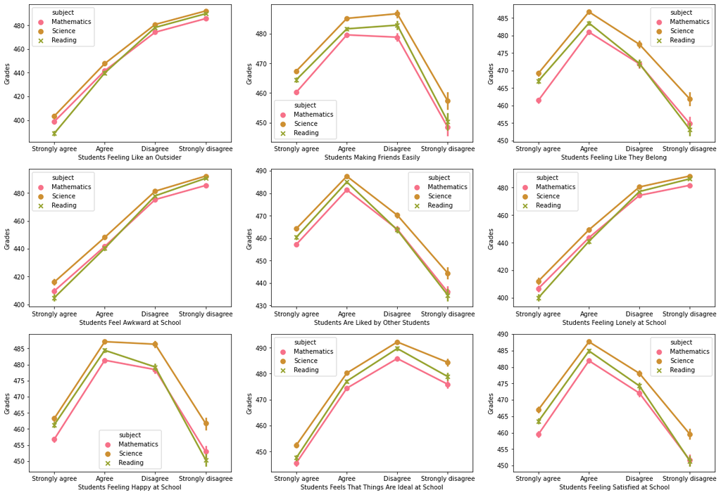

```python
#create a series of line plots to investigate sense of belonging and grades

fig, axes = plt.subplots(ncols=3,nrows=3,figsize=(20,14))
ax1, ax2, ax3, ax4, ax5, ax6, ax7, ax8, ax9 = axes.flatten()

def makegraph(num_ax,xaxis,xlabel):
    num_ax = sb.pointplot(ax=num_ax, data = sense_bel_df, x = xaxis, y='grade', hue='subject', palette=sb.color_palette('husl', 8),
                      markers=["o", "o","x"], linestyles=["-", "-", "-"])
    num_ax.set_xlabel(xlabel)
    num_ax.set_ylabel("Grades");

makegraph(ax1,"outsider","Students Feeling Like an Outsider")
makegraph(ax2,"make_friends","Students Making Friends Easily")
makegraph(ax3,"belonging","Students Feeling Like They Belong")
makegraph(ax4,"feeling_awkard","Students Feel Awkward at School")
makegraph(ax5,"liked","Students Are Liked by Other Students")
makegraph(ax6,"feeling_lonely","Students Feeling Lonely at School")
makegraph(ax7,"feeling_happy","Students Feeling Happy at School")
makegraph(ax8,"ideal_school","Students Feels That Things Are Ideal at School")
makegraph(ax9,"satisfication","Students Feeling Satisfied at School")
```

## Attitude Towards School and Grades

Generally, when students have a good attitude towards school, they will have better grades. For example, when they feel like school prepares you for life, it isn't a waste of time, it is useful for their future, they feel happy getting good grades, and they believe that trying hard is important, they will have better grades than those who have a bad attitude towards school.

```python
attitude_df = pd.melt(df_clean, id_vars=["student_ID","country","little_prep","waste_time",
                                         "confidence","useful_job","helps_job","prep_college","enjoy_grades","try_hard"],
               value_vars=["maths_avg","sci_avg","read_avg"],
               var_name="subject", value_name='grade')
attitude_df['subject'] = attitude_df['subject'].replace("maths_avg", "Mathematics").replace("read_avg",'Reading').replace("sci_avg","Science")
```

[figure not shown]

```python
#create a series of line plots to investigate attitude towards school and grades

fig, axes = plt.subplots(ncols=4,nrows=2,figsize=(25,9))
ax1, ax2, ax3, ax4, ax5, ax6, ax7, ax8 = axes.flatten()

def makegraph(num_ax,xaxis,xlabel):
    num_ax = sb.pointplot(ax=num_ax, data = attitude_df, x = xaxis, y='grade', hue='subject', palette=sb.color_palette('husl', 8),
                      markers=["o", "o","x"], linestyles=["-", "-", "-"])
    num_ax.set_xlabel(xlabel)
    num_ax.set_ylabel("Grades");

makegraph(ax1,"little_prep","Students Feeling Like an Outsider")
makegraph(ax2,"waste_time","Students Making Friends Easily")
makegraph(ax3,"confidence","Students Feeling Like They Belong")
makegraph(ax4,"useful_job","Students Feel Awkward at School")
makegraph(ax5,"helps_job","Students Are Liked by Other Students")
makegraph(ax6,"prep_college","Students Feeling Lonely at School")
makegraph(ax7,"enjoy_grades","Students Feeling Happy at School")
makegraph(ax8,"try_hard","Students Feels That Things Are Ideal at School")
```